# E013 Pho4 chimera activity analysis using PHO5 reporter, analysis

Bin He

2023-10-31 updated 2025-02-13

```r
require(plotly)
require(tidyverse)
require(ggridges)
require(cowplot)
require(RColorBrewer)
require(grid)
require(ggtext)
```

```r
old <- theme_set(theme_bw(base_size = 16))
```

This is the second part of the analysis. In the first part (see `../input/PHO5-data/20231019-pool-qc-PHO5.Rmd`), I did QC and exported the filtered dataset. Here, I will continue working with that dataset and answer our biological questions.

# Goal

- Analyze the full chimera set flow results for *PHO5pr*-mCherry reporter.
- Develop an analysis pipeline to perform QC, correction (if needed) and plotting the results.

# Data

Import the background subtracted data

```r
dat0 <- read_tsv("../input/20231023-PHO5-bg-subtracted-data.tsv", col_types = "ccccdddddc")
```

Filter the data

```r
dat <- filter(dat0, host != "PHO84", flag == "pass", date != "02/10") %>%
  # based on previous QC, the following sample (both replicates) have high
  # variance - one biological replicate is highly expressed, while the other
  # two have mNeon, but barely any RFP expression.
  mutate(
    host = fct_recode(host, pho2 = "pho2∆"),
    flag = ifelse(plasmid == "233" & host == "pho2", "high.var", flag))
```

Number of replicates left for each sample

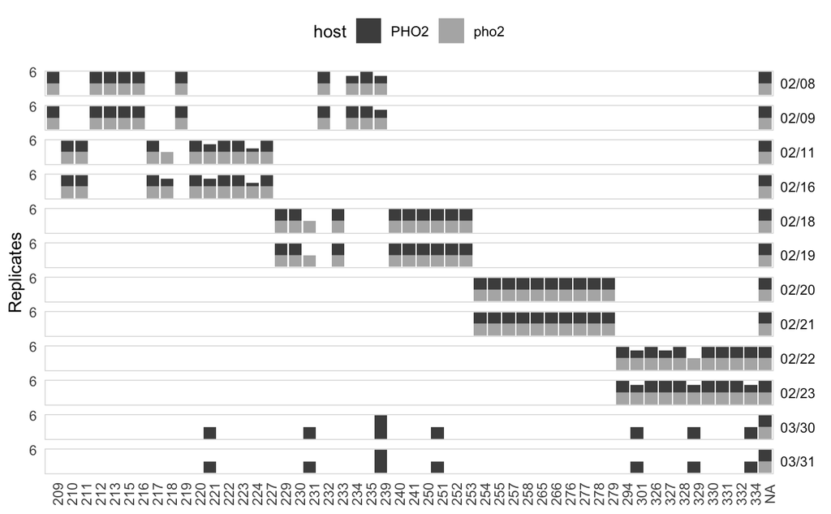

```r
expt <- dat %>%
  filter(host %in% c("PHO2", "pho2"), !plasmid %in% c("188", "194")) %>%
  group_by(date, plasmid, host) %>%
  summarize(n = n(), .groups = "drop")

expt %>%
  ggplot(aes(x = plasmid, y = n)) +
  geom_col(aes(fill = host)) +
  facet_grid(date ~ .) +
  scale_fill_manual(values = c("PHO2" = "gray30", "pho2" = "gray70")) +
  theme_minimal() + background_grid(major = "none") + panel_border(size = 0.5) +
  scale_y_continuous(name = "Replicates", breaks = c(6)) + xlab(NULL) +
  theme(axis.text.x = element_text(angle = 90),
        strip.text.y = element_text(angle = 0),
        legend.position = "top")
```

Chimera makeup information

```r
meta <- read_tsv("../input/20230208-chimera-Pho4-makeup.txt", col_types = "ccccc")
```